# StockMarketAnalysis

[figure not shown]

## STOCK MARKET ANALYSIS

We'll be analyzing stock data related to a Three Canadian Energy Companies, from Jan 1 2017 to April 21 2023. The companies are:

##### 1) B2Gold Corp (BTO.TO)

##### 2) Tamarack Valley Energy(TVE.TO)

##### 3) Arbor Metals Corp (ABR.V)

## Part 0 : Import Lybraries

```python
import pandas as pd
import datetime as dt
import yfinance as yf
import numpy as np
import math
import matplotlib.pyplot as plt
%matplotlib inline
```

## Part 1 : Getting Data

### B2Gold Corp

```python
company1 = 'BTO.TO'
start = dt.datetime(2017,1,1)
end = dt.datetime(2023,4,21)
dataBTO = yf.download(company1,start,end)
```

```
[*********************100%***********************]  1 of 1 completed
```

```python
dataBTO.head(10)
```

| Date | Open | High | Low | Close | Adj Close | Volume |
| --- | --- | --- | --- | --- | --- | --- |
| 2017-01-03 | 3.24 | 3.39 | 3.20 | 3.39 | 3.017571 | 7465100 |
| 2017-01-04 | 3.44 | 3.45 | 3.32 | 3.36 | 2.990867 | 7361500 |
| 2017-01-05 | 3.45 | 3.72 | 3.44 | 3.68 | 3.275711 | 16209900 |
| 2017-01-06 | 3.58 | 3.70 | 3.47 | 3.56 | 3.168895 | 11437400 |
| 2017-01-09 | 3.66 | 3.71 | 3.55 | 3.57 | 3.177796 | 8227400 |
| 2017-01-10 | 3.60 | 3.70 | 3.60 | 3.64 | 3.240106 | 7229300 |
| 2017-01-11 | 3.63 | 3.70 | 3.51 | 3.63 | 3.231204 | 8585200 |
| 2017-01-12 | 3.70 | 3.75 | 3.56 | 3.61 | 3.213402 | 6740400 |
| 2017-01-13 | 3.57 | 3.65 | 3.49 | 3.64 | 3.240106 | 6482100 |
| 2017-01-16 | 3.68 | 3.70 | 3.64 | 3.68 | 3.275711 | 1891700 |

```python
dataBTO.to_csv(r'H:\Data Science\Day Trading\python -finances\dataBTO.csv', index=True, encoding = "utf-8")
```

### Tamarack Valley Energy

```python
company2 = 'TVE.TO'
start = dt.datetime(2017,1,1)
end = dt.datetime(2023,4,21)
dataTVE = yf.download(company2,start,end)
```

```
[*********************100%***********************]  1 of 1 completed
```

```python
dataTVE.head(10)
```

| Date | Open | High | Low | Close | Adj Close | Volume |
| --- | --- | --- | --- | --- | --- | --- |
| 2017-01-03 | 3.51 | 3.58 | 3.24 | 3.32 | 3.196805 | 1732700 |
| 2017-01-04 | 3.31 | 3.41 | 3.26 | 3.31 | 3.187176 | 717300 |
| 2017-01-05 | 3.35 | 3.48 | 3.33 | 3.47 | 3.341239 | 4660500 |
| 2017-01-06 | 3.50 | 3.59 | 3.45 | 3.53 | 3.399013 | 853600 |
| 2017-01-09 | 3.49 | 3.55 | 3.44 | 3.47 | 3.341239 | 539000 |
| 2017-01-10 | 3.48 | 3.50 | 3.43 | 3.45 | 3.321981 | 589200 |
| 2017-01-11 | 3.47 | 3.51 | 3.44 | 3.44 | 3.312353 | 480200 |
| 2017-01-12 | 3.53 | 3.53 | 3.43 | 3.50 | 3.370126 | 232700 |
| 2017-01-13 | 3.45 | 3.52 | 3.44 | 3.48 | 3.350868 | 108200 |
| 2017-01-16 | 3.48 | 3.48 | 3.37 | 3.40 | 3.273837 | 264500 |

```python
dataTVE.to_csv(r'H:\Data Science\Day Trading\python -finances\dataTVE.csv', index=True, encoding = "utf-8")
```

### Arbor Metals Corp

```python
company3 = 'ABR.V'
start = dt.datetime(2017,1,1)
end = dt.datetime(2023,4,21)
dataABR = yf.download(company3,start,end)
```

```
[*********************100%***********************]  1 of 1 completed
```

```python
dataABR.head(10)
```

| Date | Open | High | Low | Close | Adj Close | Volume |
| --- | --- | --- | --- | --- | --- | --- |
| 2017-01-03 | 0.068571 | 0.068571 | 0.068571 | 0.068571 | 0.068571 | 0 |
| 2017-01-04 | 0.068571 | 0.068571 | 0.068571 | 0.068571 | 0.068571 | 0 |
| 2017-01-05 | 0.068571 | 0.068571 | 0.068571 | 0.068571 | 0.068571 | 0 |
| 2017-01-06 | 0.068571 | 0.068571 | 0.068571 | 0.068571 | 0.068571 | 0 |
| 2017-01-09 | 0.068571 | 0.068571 | 0.068571 | 0.068571 | 0.068571 | 0 |
| 2017-01-10 | 0.068571 | 0.068571 | 0.068571 | 0.068571 | 0.068571 | 0 |
| 2017-01-11 | 0.068571 | 0.068571 | 0.068571 | 0.068571 | 0.068571 | 3500 |
| 2017-01-12 | 0.068571 | 0.068571 | 0.068571 | 0.068571 | 0.068571 | 0 |
| 2017-01-13 | 0.068571 | 0.068571 | 0.068571 | 0.068571 | 0.068571 | 0 |
| 2017-01-16 | 0.068571 | 0.068571 | 0.068571 | 0.068571 | 0.068571 | 0 |

```python
dataABR.to_csv(r'H:\Data Science\Day Trading\python -finances\dataABR.csv', index=True, encoding = "utf-8")
```

## Part 2: Visualizing Data

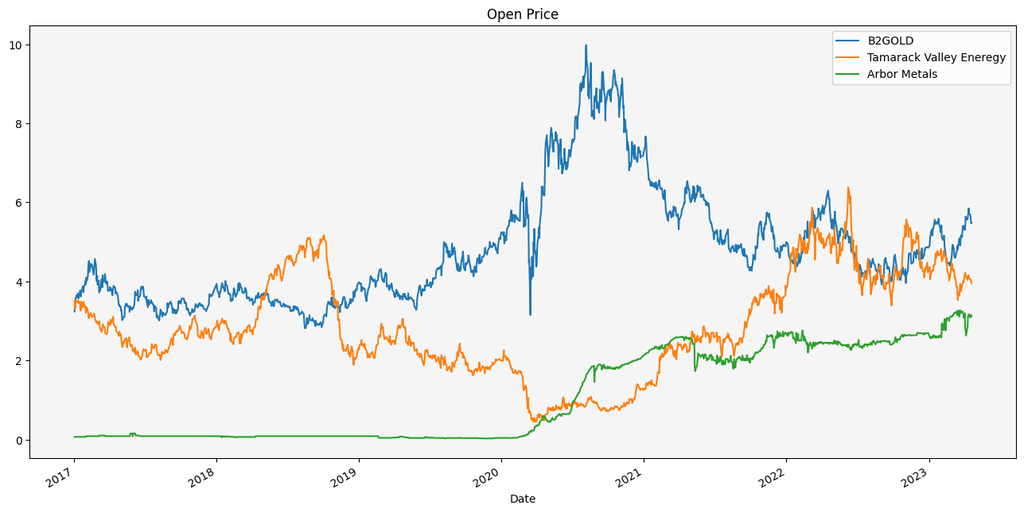

```python
ax=plt.axes()
ax.set_facecolor('whitesmoke')
dataBTO['Open'].plot(label='B2GOLD',figsize=(16,8),title='Open Price')
dataTVE['Open'].plot(label='Tamarack Valley Eneregy')
dataABR['Open'].plot(label='Arbor Metals')
plt.legend()
```

### Plot the Volume of Stock Traded each day

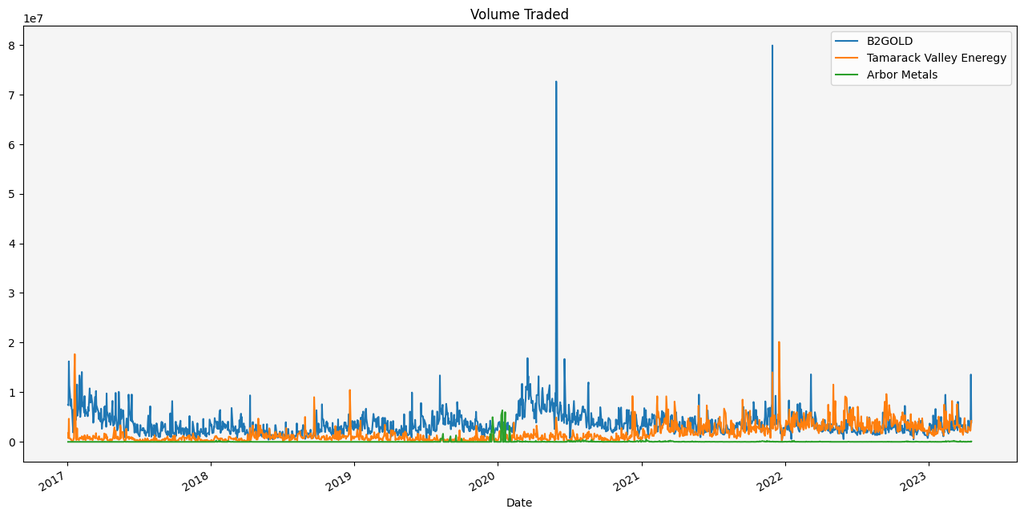

```python
ax=plt.axes()
ax.set_facecolor('whitesmoke')
dataBTO['Volume'].plot(label='B2GOLD',figsize=(16,8),title='Volume Traded')
dataTVE['Volume'].plot(label='Tamarack Valley Eneregy')
dataABR['Volume'].plot(label='Arbor Metals')
plt.legend()
```

** Interesting, looks like B2GOLD had a really big spike somewhere in late 2021. What was the date of this maximum trading volume for B2GOLD?**

**What happened that day?**

** Obtain the exactly Date of this maximum trading volume

```python
dataBTO[dataBTO['Volume']==dataBTO['Volume'].max()]
```

| Date | Open | High | Low | Close | Adj Close | Volume |
| --- | --- | --- | --- | --- | --- | --- |
| 2021-11-30 | 5.17 | 5.28 | 5.03 | 5.06 | 4.739866 | 79861800 |

#### what happened this date?(2021-11-30):

https://stockhouse.com/news/press-releases/2021/11/30/b2gold-completes-the-sale-of-burkina-faso-projects#:~:text=VANCOUVER%2C%20BC%2C%20November%2030%2C%202021%20%2FPRNewswire%2F%20-%20B2Gold,%28%22%20WAF%20%22%29%20%28the%20%22%20Kiaka%20Transaction%20%22%29.

"is pleased to announce that it has completed the sale of its 81% interest in the Kiaka gold project located in Burkina Faso (the "Kiaka Project") to West African Resources Limited (ASX:WAF) ("WAF")(the "Kiaka Transaction"). Pursuant to the terms of the Kiaka Transaction, on closing B2Gold received a cash payment of US$22.5 million (in addition to the US$450,000 already received), 22,190,508 ordinary shares of WAF ("WAF Shares"), and a 2.7% net smelter return ("NSR") royalty interest on the first 2,500,000 ounces of gold produced at the Kiaka Project and thereafter a 0.45% NSR royalty interest on the next 1,500,000 ounces of gold produced"

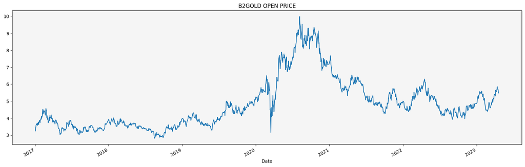

```python
ax=plt.axes()
ax.set_facecolor('whitesmoke')
dataBTO['Open'].plot(figsize=(20,6))
plt.title('B2GOLD OPEN PRICE')
```

### Calculate the Total Amount of Money being Traded around

```python
dataBTO['Total Traded'] = dataBTO['Open']*dataBTO['Volume']
dataTVE['Total Traded'] = dataTVE['Open']*dataTVE['Volume']
dataABR['Total Traded'] = dataABR['Open']*dataABR['Volume']
```

```python
dataBTO.head(10)
```

| Date | Open | High | Low | Close | Adj Close | Volume | Total Traded |
| --- | --- | --- | --- | --- | --- | --- | --- |
| 2017-01-03 | 3.24 | 3.39 | 3.20 | 3.39 | 3.017571 | 7465100 | 2.418692e+07 |
| 2017-01-04 | 3.44 | 3.45 | 3.32 | 3.36 | 2.990867 | 7361500 | 2.532356e+07 |
| 2017-01-05 | 3.45 | 3.72 | 3.44 | 3.68 | 3.275711 | 16209900 | 5.592416e+07 |
| 2017-01-06 | 3.58 | 3.70 | 3.47 | 3.56 | 3.168895 | 11437400 | 4.094589e+07 |
| 2017-01-09 | 3.66 | 3.71 | 3.55 | 3.57 | 3.177796 | 8227400 | 3.011228e+07 |
| 2017-01-10 | 3.60 | 3.70 | 3.60 | 3.64 | 3.240106 | 7229300 | 2.602548e+07 |
| 2017-01-11 | 3.63 | 3.70 | 3.51 | 3.63 | 3.231204 | 8585200 | 3.116428e+07 |
| 2017-01-12 | 3.70 | 3.75 | 3.56 | 3.61 | 3.213402 | 6740400 | 2.493948e+07 |
| 2017-01-13 | 3.57 | 3.65 | 3.49 | 3.64 | 3.240106 | 6482100 | 2.314110e+07 |
| 2017-01-16 | 3.68 | 3.70 | 3.64 | 3.68 | 3.275711 | 1891700 | 6.961456e+06 |

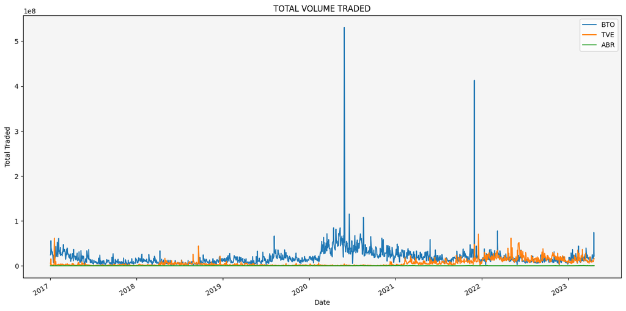

```python
ax=plt.axes()
ax.set_facecolor('whitesmoke')
dataBTO['Total Traded'].plot(label='BTO',figsize=(16,8))
dataTVE['Total Traded'].plot(label='TVE')
dataABR['Total Traded'].plot(label='ABR')
plt.legend()
plt.ylabel('Total Traded')
plt.title('TOTAL VOLUME TRADED')
```

Interesting, looks like there was huge amount of money traded for BTO somewhere in the middle of 2020 and late 2021. What date was that and what happened?

What hapenned those days?

Obtain the exactly Date of this maximum trading volume.

```python
dataBTO[dataBTO['Total Traded']==dataBTO['Total Traded'].max()]
```

| Date | Open | High | Low | Close | Adj Close | Volume | Total Traded |
| --- | --- | --- | --- | --- | --- | --- | --- |
| 2020-05-29 | 7.31 | 7.61 | 7.29 | 7.59 | 6.789467 | 72605900 | 5.307491e+08 |

```python
dataBTO['Total Traded'].nlargest(2)
```

```
Date
2020-05-29    5.307491e+08
2021-11-30    4.128855e+08
Name: Total Traded, dtype: float64
```

The results show the same previous dates as maximum volume of stock traded.

### Plotting out Moving Averages (MA) for B2GOLD. MA50 and MA200

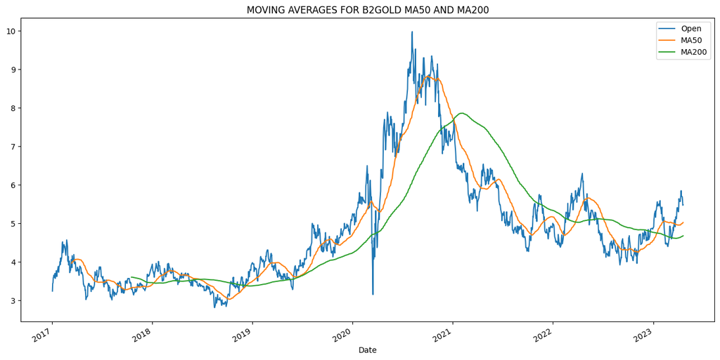

```python
dataBTO['MA50'] = dataBTO['Open'].rolling(50).mean()
dataBTO['MA200'] = dataBTO['Open'].rolling(200).mean()
dataBTO[['Open','MA50','MA200']].plot(label='BTO',figsize=(16,8), title = 'MOVING AVERAGES FOR B2GOLD MA50 AND MA200');
```

Doing the Moving Averages analysis for 50 and 200 average days (MA50, MA200), we can conclude that when the MA50 line is above the MA200 line, the price tends to rise, on the contrary, when the MA50 line is below the MA200 line, the price tends to go down. Observing the graph, we can see that the price of the stock for B2GOLD is rising.

### Figure out if there is a relationship between these stocks

```python
from pandas.plotting import scatter_matrix
```

```python
Stock_comp = pd.concat([dataBTO['Open'],dataTVE['Open'],dataABR['Open']],axis=1)
```

```python
Stock_comp.head(-10)
```

| Date | Open | Open | Open |
| --- | --- | --- | --- |
| 2017-01-03 | 3.24 | 3.51 | 0.068571 |
| 2017-01-04 | 3.44 | 3.31 | 0.068571 |
| 2017-01-05 | 3.45 | 3.35 | 0.068571 |
| 2017-01-06 | 3.58 | 3.50 | 0.068571 |
| 2017-01-09 | 3.66 | 3.49 | 0.068571 |
| ... | ... | ... | ... |
| 2023-03-30 | 5.41 | 4.01 | 3.190000 |
| 2023-03-31 | 5.40 | 3.98 | 3.080000 |
| 2023-04-03 | 5.30 | 4.20 | 3.190000 |
| 2023-04-04 | 5.37 | 4.22 | 2.800000 |
| 2023-04-05 | 5.64 | 4.15 | 2.750000 |

1571 rows × 3 columns

```python
Stock_comp.columns = ['BTO Open','TVE Open','ABR Open']
Stock_comp.columns
```

```
Index(['BTO Open', 'TVE Open', 'ABR Open'], dtype='object')
```

```python
Stock_comp.head(10)
```

| Date | BTO Open | TVE Open | ABR Open |
| --- | --- | --- | --- |
| 2017-01-03 | 3.24 | 3.51 | 0.068571 |
| 2017-01-04 | 3.44 | 3.31 | 0.068571 |
| 2017-01-05 | 3.45 | 3.35 | 0.068571 |
| 2017-01-06 | 3.58 | 3.50 | 0.068571 |
| 2017-01-09 | 3.66 | 3.49 | 0.068571 |
| 2017-01-10 | 3.60 | 3.48 | 0.068571 |
| 2017-01-11 | 3.63 | 3.47 | 0.068571 |
| 2017-01-12 | 3.70 | 3.53 | 0.068571 |
| 2017-01-13 | 3.57 | 3.45 | 0.068571 |
| 2017-01-16 | 3.68 | 3.48 | 0.068571 |

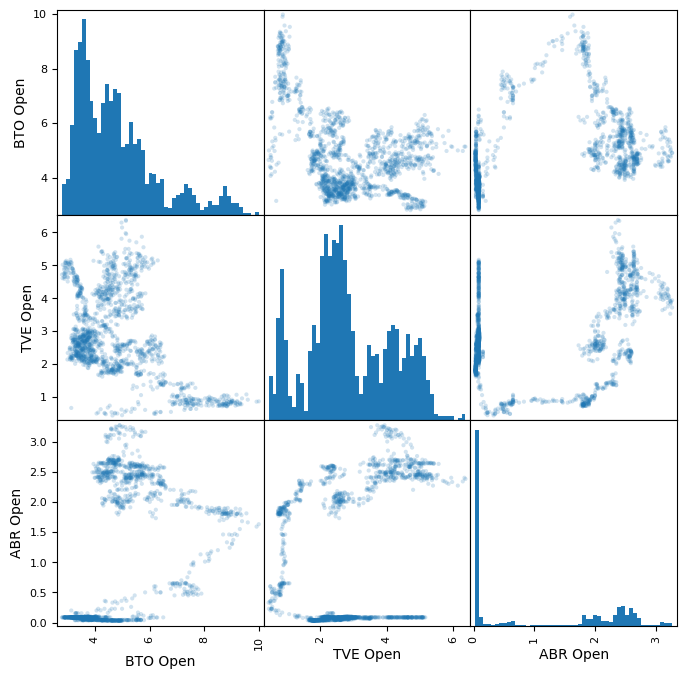

```python
scatter_matrix(Stock_comp,figsize=(8,8),alpha=0.2,hist_kwds={'bins':50});
```

We can see in the graph that there is an inverse correlation between TVE and BTO, when the price of BTO goes up, the price of TVE goes down and vice versa.

### Candlestick chart for B2GOLD: March 2023

```python
import mplfinance
from mplfinance.original_flavor import candlestick_ohlc
from matplotlib.dates import DateFormatter, date2num, WeekdayLocator, DayLocator, MONDAY
```

```python
dataBTO_reset=dataBTO.loc['2023-03'].reset_index()
```

```python
dataBTO_reset
```

|  | Date | Open | High | Low | Close | Adj Close | Volume | Total Traded | MA50 | MA200 |
| --- | --- | --- | --- | --- | --- | --- | --- | --- | --- | --- |
| 0 | 2023-03-01 | 4.70 | 4.92 | 4.69 | 4.88 | 4.824639 | 5435300 | 2.554591e+07 | 5.0152 | 4.64210 |
| 1 | 2023-03-02 | 4.87 | 4.87 | 4.77 | 4.84 | 4.785092 | 3840600 | 1.870372e+07 | 5.0210 | 4.64165 |
| 2 | 2023-03-03 | 4.93 | 4.94 | 4.81 | 4.85 | 4.794979 | 2396500 | 1.181474e+07 | 5.0266 | 4.64065 |
| 3 | 2023-03-06 | 4.81 | 4.83 | 4.73 | 4.76 | 4.706000 | 2835200 | 1.363731e+07 | 5.0292 | 4.63835 |
| 4 | 2023-03-07 | 4.65 | 4.66 | 4.54 | 4.59 | 4.590000 | 2253000 | 1.047645e+07 | 5.0260 | 4.63585 |
| 5 | 2023-03-08 | 4.60 | 4.66 | 4.52 | 4.56 | 4.560000 | 4198400 | 1.931264e+07 | 5.0222 | 4.63285 |
| 6 | 2023-03-09 | 4.60 | 4.62 | 4.51 | 4.51 | 4.510000 | 2529500 | 1.163570e+07 | 5.0170 | 4.62915 |
| 7 | 2023-03-10 | 4.61 | 4.69 | 4.57 | 4.60 | 4.600000 | 3805100 | 1.754151e+07 | 5.0118 | 4.62550 |
| 8 | 2023-03-13 | 4.76 | 4.86 | 4.72 | 4.80 | 4.800000 | 5264900 | 2.506093e+07 | 5.0096 | 4.62280 |
| 9 | 2023-03-14 | 4.77 | 4.83 | 4.71 | 4.80 | 4.800000 | 2805700 | 1.338319e+07 | 5.0080 | 4.62020 |
| 10 | 2023-03-15 | 4.90 | 4.95 | 4.79 | 4.83 | 4.830000 | 3293300 | 1.613717e+07 | 5.0078 | 4.61845 |
| 11 | 2023-03-16 | 4.81 | 4.86 | 4.69 | 4.83 | 4.830000 | 2344000 | 1.127464e+07 | 5.0020 | 4.61670 |
| 12 | 2023-03-17 | 4.91 | 5.06 | 4.82 | 5.01 | 5.010000 | 8059100 | 3.957018e+07 | 4.9970 | 4.61565 |
| 13 | 2023-03-20 | 5.09 | 5.09 | 5.00 | 5.08 | 5.080000 | 3616400 | 1.840748e+07 | 4.9938 | 4.61570 |
| 14 | 2023-03-21 | 4.98 | 5.02 | 4.88 | 4.91 | 4.910000 | 3798300 | 1.891553e+07 | 4.9870 | 4.61485 |
| 15 | 2023-03-22 | 4.91 | 5.07 | 4.89 | 4.99 | 4.990000 | 3857100 | 1.893836e+07 | 4.9820 | 4.61295 |
| 16 | 2023-03-23 | 5.03 | 5.19 | 4.98 | 5.14 | 5.140000 | 4816800 | 2.422851e+07 | 4.9766 | 4.61175 |
| 17 | 2023-03-24 | 5.17 | 5.26 | 5.13 | 5.22 | 5.220000 | 3206600 | 1.657812e+07 | 4.9732 | 4.61185 |
| 18 | 2023-03-27 | 5.12 | 5.31 | 5.07 | 5.29 | 5.290000 | 3082100 | 1.578035e+07 | 4.9682 | 4.61175 |
| 19 | 2023-03-28 | 5.30 | 5.46 | 5.29 | 5.45 | 5.450000 | 3397900 | 1.800887e+07 | 4.9630 | 4.61255 |
| 20 | 2023-03-29 | 5.40 | 5.45 | 5.36 | 5.38 | 5.380000 | 3368000 | 1.818720e+07 | 4.9618 | 4.61465 |
| 21 | 2023-03-30 | 5.41 | 5.44 | 5.37 | 5.40 | 5.400000 | 2256300 | 1.220658e+07 | 4.9608 | 4.61605 |
| 22 | 2023-03-31 | 5.40 | 5.42 | 5.32 | 5.34 | 5.340000 | 2998700 | 1.619298e+07 | 4.9598 | 4.61805 |

```python
dataBTO_reset['date_ax']=dataBTO_reset['Date'].apply(lambda date:date2num(date))
```

```python
dataBTO_reset
```

|  | Date | Open | High | Low | Close | Adj Close | Volume | Total Traded | MA50 | MA200 | date_ax |
| --- | --- | --- | --- | --- | --- | --- | --- | --- | --- | --- | --- |
| 0 | 2023-03-01 | 4.70 | 4.92 | 4.69 | 4.88 | 4.824639 | 5435300 | 2.554591e+07 | 5.0152 | 4.64210 | 19417.0 |
| 1 | 2023-03-02 | 4.87 | 4.87 | 4.77 | 4.84 | 4.785092 | 3840600 | 1.870372e+07 | 5.0210 | 4.64165 | 19418.0 |
| 2 | 2023-03-03 | 4.93 | 4.94 | 4.81 | 4.85 | 4.794979 | 2396500 | 1.181474e+07 | 5.0266 | 4.64065 | 19419.0 |
| 3 | 2023-03-06 | 4.81 | 4.83 | 4.73 | 4.76 | 4.706000 | 2835200 | 1.363731e+07 | 5.0292 | 4.63835 | 19422.0 |
| 4 | 2023-03-07 | 4.65 | 4.66 | 4.54 | 4.59 | 4.590000 | 2253000 | 1.047645e+07 | 5.0260 | 4.63585 | 19423.0 |
| 5 | 2023-03-08 | 4.60 | 4.66 | 4.52 | 4.56 | 4.560000 | 4198400 | 1.931264e+07 | 5.0222 | 4.63285 | 19424.0 |
| 6 | 2023-03-09 | 4.60 | 4.62 | 4.51 | 4.51 | 4.510000 | 2529500 | 1.163570e+07 | 5.0170 | 4.62915 | 19425.0 |
| 7 | 2023-03-10 | 4.61 | 4.69 | 4.57 | 4.60 | 4.600000 | 3805100 | 1.754151e+07 | 5.0118 | 4.62550 | 19426.0 |
| 8 | 2023-03-13 | 4.76 | 4.86 | 4.72 | 4.80 | 4.800000 | 5264900 | 2.506093e+07 | 5.0096 | 4.62280 | 19429.0 |
| 9 | 2023-03-14 | 4.77 | 4.83 | 4.71 | 4.80 | 4.800000 | 2805700 | 1.338319e+07 | 5.0080 | 4.62020 | 19430.0 |
| 10 | 2023-03-15 | 4.90 | 4.95 | 4.79 | 4.83 | 4.830000 | 3293300 | 1.613717e+07 | 5.0078 | 4.61845 | 19431.0 |
| 11 | 2023-03-16 | 4.81 | 4.86 | 4.69 | 4.83 | 4.830000 | 2344000 | 1.127464e+07 | 5.0020 | 4.61670 | 19432.0 |
| 12 | 2023-03-17 | 4.91 | 5.06 | 4.82 | 5.01 | 5.010000 | 8059100 | 3.957018e+07 | 4.9970 | 4.61565 | 19433.0 |
| 13 | 2023-03-20 | 5.09 | 5.09 | 5.00 | 5.08 | 5.080000 | 3616400 | 1.840748e+07 | 4.9938 | 4.61570 | 19436.0 |
| 14 | 2023-03-21 | 4.98 | 5.02 | 4.88 | 4.91 | 4.910000 | 3798300 | 1.891553e+07 | 4.9870 | 4.61485 | 19437.0 |
| 15 | 2023-03-22 | 4.91 | 5.07 | 4.89 | 4.99 | 4.990000 | 3857100 | 1.893836e+07 | 4.9820 | 4.61295 | 19438.0 |
| 16 | 2023-03-23 | 5.03 | 5.19 | 4.98 | 5.14 | 5.140000 | 4816800 | 2.422851e+07 | 4.9766 | 4.61175 | 19439.0 |
| 17 | 2023-03-24 | 5.17 | 5.26 | 5.13 | 5.22 | 5.220000 | 3206600 | 1.657812e+07 | 4.9732 | 4.61185 | 19440.0 |
| 18 | 2023-03-27 | 5.12 | 5.31 | 5.07 | 5.29 | 5.290000 | 3082100 | 1.578035e+07 | 4.9682 | 4.61175 | 19443.0 |
| 19 | 2023-03-28 | 5.30 | 5.46 | 5.29 | 5.45 | 5.450000 | 3397900 | 1.800887e+07 | 4.9630 | 4.61255 | 19444.0 |
| 20 | 2023-03-29 | 5.40 | 5.45 | 5.36 | 5.38 | 5.380000 | 3368000 | 1.818720e+07 | 4.9618 | 4.61465 | 19445.0 |
| 21 | 2023-03-30 | 5.41 | 5.44 | 5.37 | 5.40 | 5.400000 | 2256300 | 1.220658e+07 | 4.9608 | 4.61605 | 19446.0 |
| 22 | 2023-03-31 | 5.40 | 5.42 | 5.32 | 5.34 | 5.340000 | 2998700 | 1.619298e+07 | 4.9598 | 4.61805 | 19447.0 |

```python
dataBTO_values = [tuple(vals) for vals in dataBTO_reset[['date_ax', 'Open', 'High', 'Low', 'Close']].values]
```

```python
dataBTO_values
```

[output not shown]

[output cut: 56 more lines]

```
 (19445.0,
  5.400000095367432,
  5.449999809265137,
  5.360000133514404,
  5.380000114440918),
 (19446.0,
  5.409999847412109,
  5.440000057220459,
  5.369999885559082,
  5.400000095367432),
 (19447.0,
  5.400000095367432,
  5.420000076293945,
  5.320000171661377,
  5.340000152587891)]
```

```python
mondays = WeekdayLocator(MONDAY)        # major ticks on the mondays
alldays = DayLocator()              # minor ticks on the days
weekFormatter = DateFormatter('%b %d')  # e.g., Jan 12
dayFormatter = DateFormatter('%d')      # e.g., 12
```

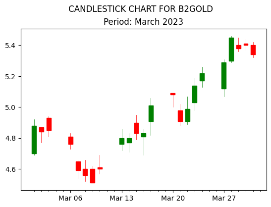

```python
#Plot it

fig, ax = plt.subplots()
fig.subplots_adjust(bottom=0.2)
ax.xaxis.set_major_locator(mondays)
ax.xaxis.set_minor_locator(alldays)
ax.xaxis.set_major_formatter(weekFormatter)
plt.title("Period: March 2023")
plt.suptitle(' CANDLESTICK CHART FOR B2GOLD')

candlestick_ohlc(ax, dataBTO_values, width=0.6, colorup='g',colordown='r');
```

## Part 3: Basic Financial Analysis

### Calculating Daily Returns

Daily Returns inform us the precentage gain or loss if we buy the stock one day and sell it the another day. This ratio is very useful in analyzing the VOLATILITY of the stock. If Daily Returns have a wide distribution, the stock is more volatile, more risky but give you more return. The formula is as follow:

$ r_t = \frac{p_t}{p_{t-1}} -1$

#### Daily Returns: B2GOLD (BTO)

```python
dataBTO['returns'] = (dataBTO['Close'] / dataBTO['Close'].shift(1) ) - 1
dataBTO.head()
```

| Date | Open | High | Low | Close | Adj Close | Volume | Total Traded | MA50 | MA200 | returns |
| --- | --- | --- | --- | --- | --- | --- | --- | --- | --- | --- |
| 2017-01-03 | 3.24 | 3.39 | 3.20 | 3.39 | 3.017571 | 7465100 | 2.418692e+07 | NaN | NaN | NaN |
| 2017-01-04 | 3.44 | 3.45 | 3.32 | 3.36 | 2.990867 | 7361500 | 2.532356e+07 | NaN | NaN | -0.008850 |
| 2017-01-05 | 3.45 | 3.72 | 3.44 | 3.68 | 3.275711 | 16209900 | 5.592416e+07 | NaN | NaN | 0.095238 |
| 2017-01-06 | 3.58 | 3.70 | 3.47 | 3.56 | 3.168895 | 11437400 | 4.094589e+07 | NaN | NaN | -0.032609 |
| 2017-01-09 | 3.66 | 3.71 | 3.55 | 3.57 | 3.177796 | 8227400 | 3.011228e+07 | NaN | NaN | 0.002809 |

```python
dataBTO['returns'] = dataBTO['Close'].pct_change(1)
dataBTO.head()
```

| Date | Open | High | Low | Close | Adj Close | Volume | Total Traded | MA50 | MA200 | returns |
| --- | --- | --- | --- | --- | --- | --- | --- | --- | --- | --- |
| 2017-01-03 | 3.24 | 3.39 | 3.20 | 3.39 | 3.017571 | 7465100 | 2.418692e+07 | NaN | NaN | NaN |
| 2017-01-04 | 3.44 | 3.45 | 3.32 | 3.36 | 2.990867 | 7361500 | 2.532356e+07 | NaN | NaN | -0.008850 |
| 2017-01-05 | 3.45 | 3.72 | 3.44 | 3.68 | 3.275711 | 16209900 | 5.592416e+07 | NaN | NaN | 0.095238 |
| 2017-01-06 | 3.58 | 3.70 | 3.47 | 3.56 | 3.168895 | 11437400 | 4.094589e+07 | NaN | NaN | -0.032609 |
| 2017-01-09 | 3.66 | 3.71 | 3.55 | 3.57 | 3.177796 | 8227400 | 3.011228e+07 | NaN | NaN | 0.002809 |

```python
coeff_var_BTO = np.std(dataBTO['returns']) / np.mean(dataBTO['returns'])
coeff_var_BTO
```

```
39.76236729652576
```

#### Daily Returns: Tamarack Valley Energy (TVE)

```python
dataTVE['returns'] = dataTVE['Close'].pct_change(1)
dataTVE.head()
```

| Date | Open | High | Low | Close | Adj Close | Volume | Total Traded | returns |
| --- | --- | --- | --- | --- | --- | --- | --- | --- |
| 2017-01-03 | 3.51 | 3.58 | 3.24 | 3.32 | 3.196805 | 1732700 | 6.081777e+06 | NaN |
| 2017-01-04 | 3.31 | 3.41 | 3.26 | 3.31 | 3.187176 | 717300 | 2.374263e+06 | -0.003012 |
| 2017-01-05 | 3.35 | 3.48 | 3.33 | 3.47 | 3.341239 | 4660500 | 1.561267e+07 | 0.048338 |
| 2017-01-06 | 3.50 | 3.59 | 3.45 | 3.53 | 3.399013 | 853600 | 2.987600e+06 | 0.017291 |
| 2017-01-09 | 3.49 | 3.55 | 3.44 | 3.47 | 3.341239 | 539000 | 1.881110e+06 | -0.016997 |

```python
coeff_var_TVE = np.std(dataTVE['returns']) / np.mean(dataTVE['returns'])
coeff_var_TVE
```

```
46.62249931509346
```

#### Daily Returns: Arbor Metals Corp (ABR)

```python
dataABR['returns'] = dataABR['Close'].pct_change(1)
dataABR.head()
```

| Date | Open | High | Low | Close | Adj Close | Volume | Total Traded | returns |
| --- | --- | --- | --- | --- | --- | --- | --- | --- |
| 2017-01-03 | 0.068571 | 0.068571 | 0.068571 | 0.068571 | 0.068571 | 0 | 0.0 | NaN |
| 2017-01-04 | 0.068571 | 0.068571 | 0.068571 | 0.068571 | 0.068571 | 0 | 0.0 | 0.0 |
| 2017-01-05 | 0.068571 | 0.068571 | 0.068571 | 0.068571 | 0.068571 | 0 | 0.0 | 0.0 |
| 2017-01-06 | 0.068571 | 0.068571 | 0.068571 | 0.068571 | 0.068571 | 0 | 0.0 | 0.0 |
| 2017-01-09 | 0.068571 | 0.068571 | 0.068571 | 0.068571 | 0.068571 | 0 | 0.0 | 0.0 |

```python
coeff_var_ABR = np.std(dataABR['returns']) / np.mean(dataABR['returns'])
coeff_var_ABR
```

```
14.47676557139699
```

### Plotting Histograms for each Stock

#### B2Gold (BTO)

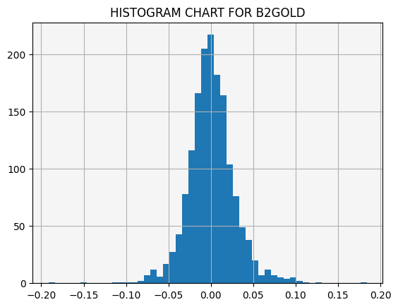

```python
ax=plt.axes()
ax.set_facecolor('whitesmoke')
dataBTO['returns'].hist(bins=50)
plt.title('HISTOGRAM CHART FOR B2GOLD');
```

Moderate Distribution

#### Tamarack Valley Energy (TVE)

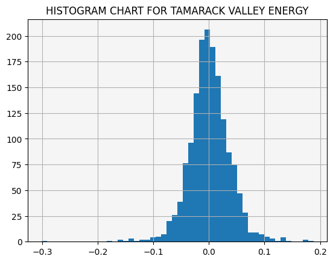

```python
ax=plt.axes()
ax.set_facecolor('whitesmoke')
dataTVE['returns'].hist(bins=50)
plt.title('HISTOGRAM CHART FOR TAMARACK VALLEY ENERGY');
```

Moderate Distribution

#### Arbor Metals Corp (ABR)

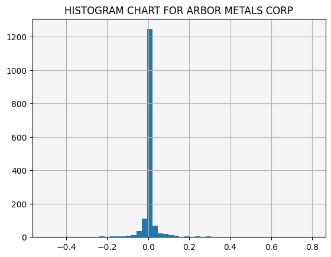

```python
ax=plt.axes()
ax.set_facecolor('whitesmoke')
dataABR['returns'].hist(bins=50)
plt.title('HISTOGRAM CHART FOR ARBOR METALS CORP');
```

Apparently show a Wide Distribution but we should take into account that for three years the Stock had not change

#### Comparing the three stocks

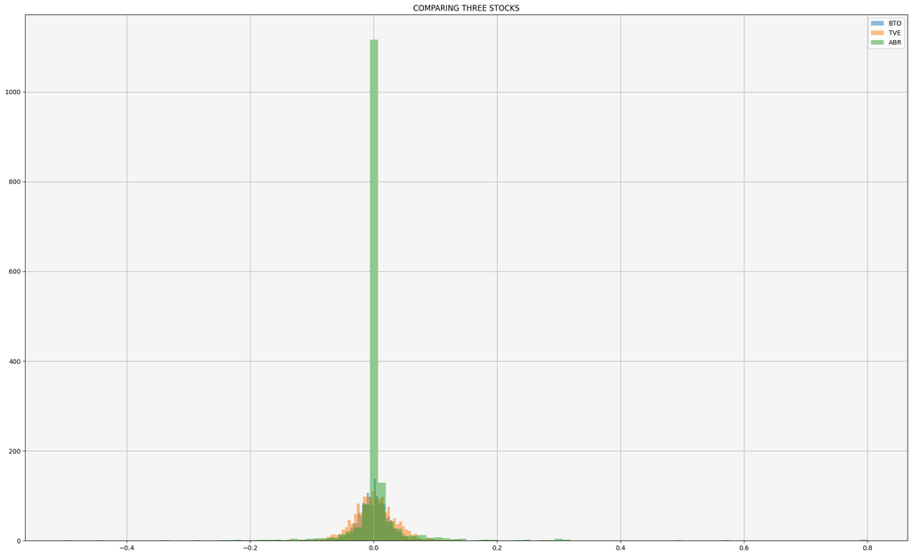

```python
ax=plt.axes()
ax.set_facecolor('whitesmoke')
dataBTO['returns'].hist(bins=100,label='BTO',figsize=(25,15),alpha=0.5)
dataTVE['returns'].hist(bins=100,label='TVE',alpha=0.5)
dataABR['returns'].hist(bins=100,label='ABR',alpha=0.5)
plt.legend();
plt.title('COMPARING THREE STOCKS')
```

Arbor Metals Corp show a Wide Distributions but the most of Returns are around Cero. TVE looks like a little be more risky than BTO.

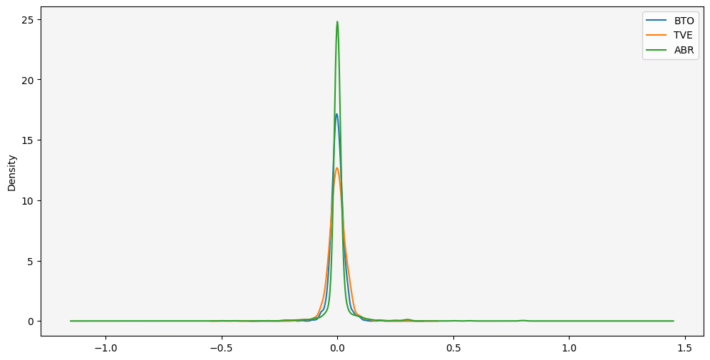

```python
ax=plt.axes()
ax.set_facecolor('whitesmoke')
dataBTO['returns'].plot(kind='kde',label='BTO',figsize=(12,6))
dataTVE['returns'].plot(kind='kde',label='TVE')
dataABR['returns'].plot(kind='kde',label='ABR')
plt.legend();
```

#### Box and whisker chart

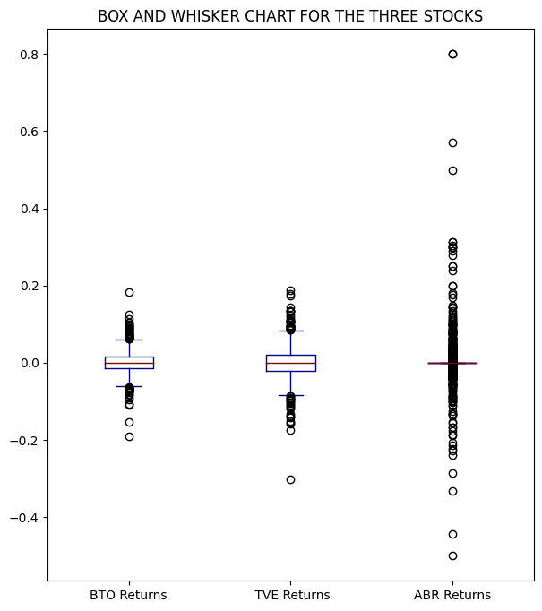

```python
box_df = pd.concat([dataBTO['returns'],dataTVE['returns'],dataABR['returns']],axis=1)
box_df.columns = ['BTO Returns',' TVE Returns','ABR Returns']
box_df.plot(kind='box',figsize=(7,8),colormap='jet')
plt.title("BOX AND WHISKER CHART FOR THE THREE STOCKS");
```

If we only analyze the graph, at first glance we could conclude that Arbor Metal Corp Stock is more volatile and therefore, riskier. But previously we calculated the coefficient of variation for each of the stocks, resulting in the following:

Coefficient of variation BTO = 39.76

Coeffiecient of Variations TVE = 46.62

Coefficient of Variations ABR = 14.48

We can see thet Tamarack Valley Energy has the highest value of the coefficient, being the most risky Stock, but could give you the highest Return.

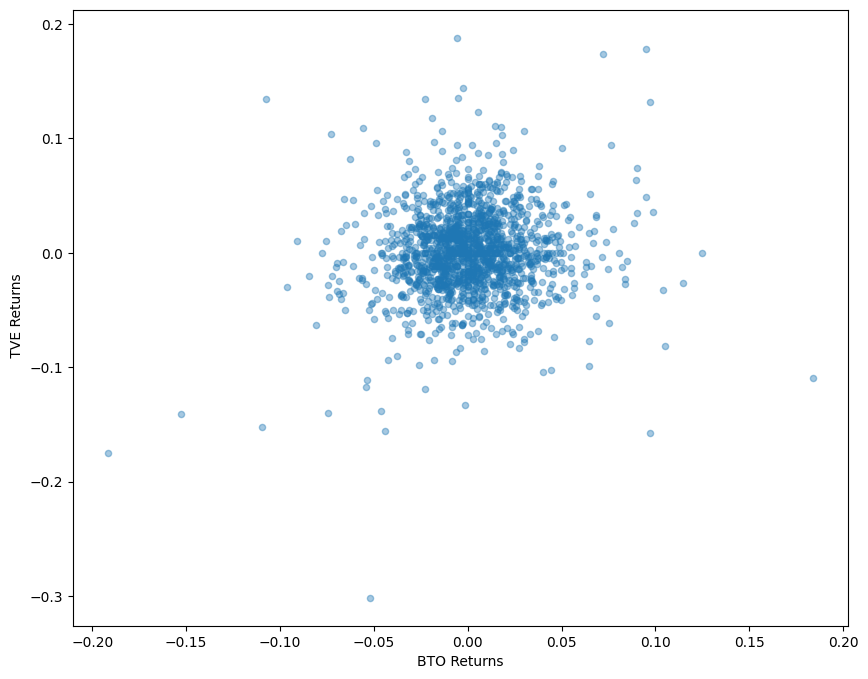

```python
box_df.plot(kind='scatter',x='BTO Returns',y=' TVE Returns',alpha=0.4,figsize=(10,8));
```

### Cumulative Daily Returns

```python
dataBTO['Cumulative Return'] = (1 + dataBTO['returns']).cumprod()
```

```python
dataBTO.head()
```

| Date | Open | High | Low | Close | Adj Close | Volume | Total Traded | MA50 | MA200 | returns | Cumulative Return |
| --- | --- | --- | --- | --- | --- | --- | --- | --- | --- | --- | --- |
| 2017-01-03 | 3.24 | 3.39 | 3.20 | 3.39 | 3.017571 | 7465100 | 2.418692e+07 | NaN | NaN | NaN | NaN |
| 2017-01-04 | 3.44 | 3.45 | 3.32 | 3.36 | 2.990867 | 7361500 | 2.532356e+07 | NaN | NaN | -0.008850 | 0.991150 |
| 2017-01-05 | 3.45 | 3.72 | 3.44 | 3.68 | 3.275711 | 16209900 | 5.592416e+07 | NaN | NaN | 0.095238 | 1.085546 |
| 2017-01-06 | 3.58 | 3.70 | 3.47 | 3.56 | 3.168895 | 11437400 | 4.094589e+07 | NaN | NaN | -0.032609 | 1.050147 |
| 2017-01-09 | 3.66 | 3.71 | 3.55 | 3.57 | 3.177796 | 8227400 | 3.011228e+07 | NaN | NaN | 0.002809 | 1.053097 |

```python
dataTVE['Cumulative Return'] = (1 + dataTVE['returns']).cumprod()
dataABR['Cumulative Return'] = (1 + dataABR['returns']).cumprod()
```

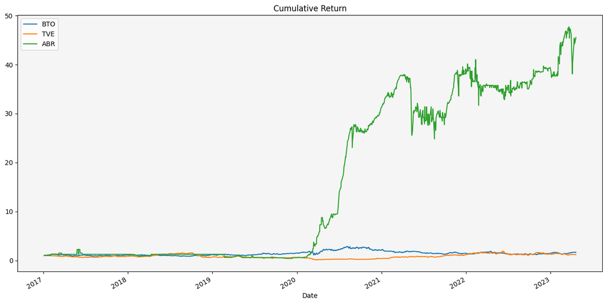

```python
ax=plt.axes()
ax.set_facecolor('whitesmoke')
dataBTO['Cumulative Return'].plot(label='BTO',figsize=(16,8),title='Cumulative Return')
dataTVE['Cumulative Return'].plot(label='TVE')
dataABR['Cumulative Return'].plot(label='ABR')
plt.legend()
```

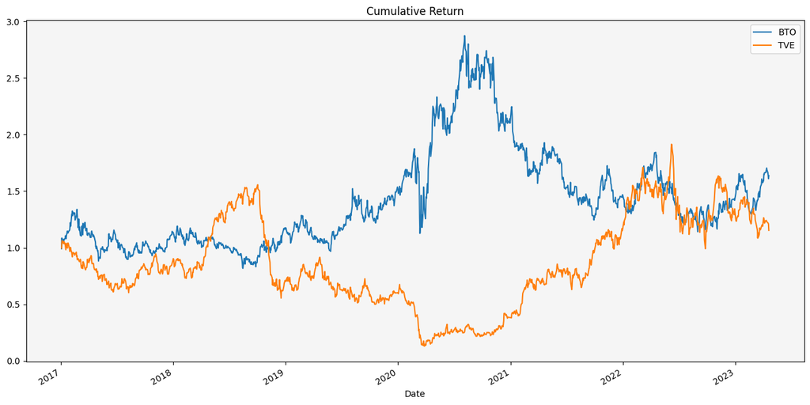

```python
ax=plt.axes()
ax.set_facecolor('whitesmoke')
dataBTO['Cumulative Return'].plot(label='BTO',figsize=(16,8),title='Cumulative Return')
dataTVE['Cumulative Return'].plot(label='TVE')
plt.legend()
```

The cumulative return shows the percentage gain or loss of the stock over time. We can see that looking at the cumulative returns of the three stocks under analysis, Arbor Metal Corp is the one that has generated the highest cumulative returns.